# Solving the heat equation

[AMath 586, Spring Quarter 2019](http://staff.washington.edu/rjl/classes/am586s2019/) at the University of Washington. For other notebooks, see Index.html or the [Index of all notebooks on Github](https://github.com/rjleveque/amath586s2019/blob/master/notebooks/Index.html).

Sample program to solve the heat equation with the Crank-Nicolson method.

We solve the heat equation $u_t = \kappa u_{xx}$ on the interval $0\leq x \leq 1$ with Dirichlet boundary conditions $u(0,t) = g_0(t)$ and $u(1,t) = g_1(t)$.

To test accuracy, we use cases where an exact solution to the heat equation for all $x$ is known. This `utrue` function is used to set initial conditions. It is also used in each time step to set boundary values on whatever finite interval we consider.

```python
%pylab inline
```

```python
from matplotlib import animation
from IPython.display import HTML
```

```python
def make_animation(hs_input, hs_output, nplot=1):

    """
    Plot every `nplot` frames of the solution and turn into
    an animation.
    """
    xfine = linspace(hs_input.ax,hs_input.bx,1001)
    fig, ax = plt.subplots()

    ax.set_xlim((hs_input.ax,hs_input.bx))
    #ax.set_ylim((-0.2, 1.2))
    ax.set_ylim((-1.2, 1.2))

    line1, = ax.plot([], [], '+-', color='b', lw=2, label='computed')
    line2, = ax.plot([], [], color='r', lw=1, label='true')
    ax.legend()
    title1 = ax.set_title('')

    def init():
        line1.set_data(hs_output.x_computed, hs_output.u_computed[:,0])
        line2.set_data(xfine, hs_input.utrue(xfine, hs_input.t0))
        title1.set_text('time t = %8.4f' % hs_input.t0)
        return (line1,line2,title1)

    def animate(n):
        line1.set_data(hs_output.x_computed, hs_output.u_computed[:,n])
        line2.set_data(xfine, hs_input.utrue(xfine, hs_output.t[n]))
        title1.set_text('time t = %8.4f' % hs_output.t[n])
        return (line1,line2,title1)

    frames = range(0, len(hs_output.t), nplot) # which frames to plot
    anim = animation.FuncAnimation(fig, animate, init_func=init,
                                   frames=frames,
                                   interval=200,
                                   blit=True)
    close('all')  # so one last frame plot doesn't remain
    return anim
```

```python
class HeatSolutionInput(object):
    def __init__(self):
        # inputs:
        self.t0 = 0.
        self.tfinal = 1.
        self.ax = 0.
        self.bx = 1.
        self.mx = 39.
        self.utrue = None
        self.kappa = 0.02
        self.nsteps = 10

class HeatSolutionOutput(object):
    def __init__(self):
        # outputs:
        self.h = None
        self.dt = None
        self.t = None
        self.x_computed = None
        self.u_computed = None
        self.errors = None
```

## Forward Euler time stepping

```python
def heat_FE(heat_solution_input):
    """
    Solve u_t = kappa * u_{xx} on [ax,bx] with Dirichlet boundary conditions,
    using centered differences in space and the Forward Euler method for time stepping,
    with m interior points, taking nsteps time steps.

    Input:
        `heat_solution_input` should be on object of class `HeatSolutionInput`
        specifying inputs.
    Output:
        an object of class `HeatSolutionOutput` with the solution and other info.

    This routine can be embedded in a loop on m to test the accuracy.

    Note: the vector x defined below is of length m+2 and includes both boundary points.
    The vector uint is of length m and is only the interior points that we solve for,
    by solving an m by m linear system each time step.

    The vector u is of length m+2 and obtained by extending uint with the boundary values,
    so that plotting (x,u) includes the boundary values.

    """


    # unpack the inputs for brevity:
    ax = heat_solution_input.ax
    bx = heat_solution_input.bx
    kappa = heat_solution_input.kappa
    m = heat_solution_input.mx
    utrue = heat_solution_input.utrue
    t0 = heat_solution_input.t0
    tfinal = heat_solution_input.tfinal
    nsteps = heat_solution_input.nsteps

    h = (bx-ax)/float(m+1)    # h = delta x
    x = linspace(ax,bx,m+2)   # note x(1)=0 and x(m+2)=1
                               # u(1)=g0 and u(m+2)=g1 are known from BC's
    dt = (tfinal - t0) / float(nsteps)

    # initial conditions:
    u0 = utrue(x,t0)


    # initialize u and plot:
    tn = 0
    u = u0

    t = empty((nsteps+1,), dtype=float)
    errors = empty((nsteps+1,), dtype=float)
    u_computed = empty((m+2,nsteps+1), dtype=float)

    t[0] = tn
    errors[0] = 0.
    u_computed[:,0] = u0


    # main time-stepping loop:

    for n in range(1,nsteps+1):
        tnp = tn + dt   # = t_{n+1}

        # indices of interior points as in integer numpy array:
        jint = array(range(1,m+1), dtype=int)

        # Then the numerical method can be written without a loop
        # or matrix-vector multiply:
        u[jint] = u[jint] + kappa * dt/h**2 * (u[jint-1] - 2*u[jint] + u[jint+1])

        # evaluate true solution to get new boundary values at tnp:
        g0np = utrue(ax,tnp)
        g1np = utrue(bx,tnp)

        # augment with boundary values:
        u[0] = g0np
        u[-1] = g1np

        error = abs(u-utrue(x,tnp)).max()  # max norm

        t[n] = tnp
        u_computed[:,n] = u
        errors[n] = error
        tn = tnp   # for next time step


    heat_solution_output = HeatSolutionOutput()  # create object for output
    heat_solution_output.dt = dt
    heat_solution_output.h = h
    heat_solution_output.t = t
    heat_solution_output.x_computed = x
    heat_solution_output.u_computed = u_computed
    heat_solution_output.errors = errors

    return heat_solution_output
```

## A smooth solution

We first use the decaying Gaussian $$ u(x,t) = \frac{1}{\sqrt{4\beta\kappa t + 1}} \exp\left(\frac{-(x-x_0)^2}{4\kappa t + 1/\beta}\right). $$ The initial data and boundary conditions are obtained by evaluating this function at $t=0$ or at $x=0$ or $x=1$. In particular, the initial conditions are simply $$ u(x,0) = \eta(x) = \exp(-\beta(x-x_0)^2). $$

```python
beta = 150
x0 = 0.4
kappa = 0.02
utrue_gaussian = lambda x,t: exp(-(x-0.4)**2 / (4*kappa*t + 1./beta)) \
            / sqrt(4*beta*kappa*t+1.)
```

Recall that the forward Euler time stepping on the heat equation is only stable if the time step satisfies $k \leq 0.5h^2/\kappa$. However, for smooth solutions with very small components of the high wave number Fourier modes, it can take a long time for the instability to appear even if we take much larger $k$. Here's an example. Note that it is the highest wave number (the saw-tooth mode) that grows fastest and hence appears first...

```python
t0 = 0.
tfinal = 4.
ax = 0.
bx = 1.
mx = 39
h = 1./((mx+1))
dt_stab = 0.5*h**2 / kappa
nsteps_stab = int(floor(tfinal-t0)/dt_stab) + 1
print('For stability, need to take at least %i time steps' % nsteps_stab)

heat_solution_input = HeatSolutionInput()
heat_solution_input.t0 = t0
heat_solution_input.tfinal = tfinal
heat_solution_input.ax = ax
heat_solution_input.bx = bx
heat_solution_input.mx = mx
heat_solution_input.utrue = utrue_gaussian
heat_solution_input.kappa = kappa
heat_solution_input.nsteps = 240

heat_solution_output = heat_FE(heat_solution_input)

error_tfinal = heat_solution_output.errors[-1]  # last element
print('Using %i time steps' % heat_solution_input.nsteps)
print('Max-norm Error at t = %6.4f is %12.8f' % (heat_solution_input.tfinal, error_tfinal))
```

```
For stability, need to take at least 256 time steps
Using 240 time steps
Max-norm Error at t = 4.0000 is  24.81118041
```

```python
# make an animation of the results, plotting every 10th frame:
anim = make_animation(heat_solution_input, heat_solution_output, nplot=10)
HTML(anim.to_jshtml())  # or use the line below...
#HTML(anim.to_html5_video())
```

[figure not shown]

Once Loop Reflect

## Discontinous initial data

The instability is observed much more quickly if the initial data contains more high wave numbers, e.g. if it is discontinuous.

Consider the exact solution $$ u(x,t) = \text{erf}\left(x/\sqrt{4\kappa t}\right) $$ where erf is the *error function* defined as the integral of the Gaussian,

$$ \text{erf}(z) = \frac{2}{\pi} \int_0^z \exp(-t^2)\, dt. $$

See e.g. https://en.wikipedia.org/wiki/Error_function.

As $t \rightarrow 0$, this approaches the discontinous function jumping from $-1$ for $x<0$ to $+1$ for $x>0$.

The error function is implemented in the `scipy.special` [library of special functions](https://docs.scipy.org/doc/scipy/reference/special.html).

```python
kappa = 0.02

def utrue_erf(x,t):
    from scipy.special import erf
    if t==0:
        return where(x>0, 1., -1.)
    else:
        return erf(x/sqrt(4*kappa*t))
```

```python
t0 = 0.
tfinal = 2.
ax = -1.
bx = 1.
mx = 40
h = (bx-ax)/((mx+1))
dt_stab = 0.5*h**2 / kappa
nsteps_stab = int(floor(tfinal-t0)/dt_stab) + 1
print('For stability, need to take at least %i time steps' % nsteps_stab)

heat_solution_input = HeatSolutionInput()
heat_solution_input.t0 = t0
heat_solution_input.tfinal = tfinal
heat_solution_input.ax = ax
heat_solution_input.bx = bx
heat_solution_input.mx = mx
heat_solution_input.utrue = utrue_erf
heat_solution_input.kappa = kappa
heat_solution_input.nsteps = 32

heat_solution_output = heat_FE(heat_solution_input)

error_tfinal = heat_solution_output.errors[-1]  # last element
print('Using %i time steps' % heat_solution_input.nsteps)
print('Max-norm Error at t = %6.4f is %12.8f' % (heat_solution_input.tfinal, error_tfinal))
```

```
For stability, need to take at least 34 time steps
Using 32 time steps
Max-norm Error at t = 2.0000 is   1.56842464
```

```python
anim = make_animation(heat_solution_input, heat_solution_output, nplot=1)
HTML(anim.to_jshtml())
```

[figure not shown]

Once Loop Reflect

## Crank-Nicolson method

This method uses the same centered difference spatial discretization with the Trapezoidal method for time stepping. That method is A-stable so this method is stable for any size time step (though not necessarily accurate).

Implementing this method requires solving a tridiagonal linear system in each time step, which we do using the [sparse matrix routines](https://docs.scipy.org/doc/scipy/reference/sparse.linalg.html) from `scipy.sparse.linalg`.

```python
def heat_CN(heat_solution_input):
    """
    Solve u_t = kappa * u_{xx} on [ax,bx] with Dirichlet boundary conditions,
    using the Crank-Nicolson method with m interior points, taking nsteps
    time steps.

    Input:
        `heat_solution_input` should be on object of class `HeatSolutionInput`
        specifying inputs.
    Output:
        an object of class `HeatSolutionOutput` with the solution and other info.

    Note: the vector x defined below is of length m+2 and includes both boundary points.
    The vector uint is of length m and is only the interior points that we solve for,
    by solving an m by m linear system each time step.

    The vector u is of length m+2 and obtained by extending uint with the boundary values,
    so that plotting (x,u) includes the boundary values.

    """

    from scipy import sparse
    from scipy.sparse.linalg import spsolve

    # unpack the inputs for brevity:
    ax = heat_solution_input.ax
    bx = heat_solution_input.bx
    kappa = heat_solution_input.kappa
    m = heat_solution_input.mx
    utrue = heat_solution_input.utrue
    t0 = heat_solution_input.t0
    tfinal = heat_solution_input.tfinal
    nsteps = heat_solution_input.nsteps

    h = (bx-ax)/float(m+1)    # h = delta x
    x = linspace(ax,bx,m+2)   # note x(1)=0 and x(m+2)=1
                               # u(1)=g0 and u(m+2)=g1 are known from BC's
    dt = tfinal / float(nsteps)

    # initial conditions:
    u0 = utrue(x,t0)

    # Each time step we solve MOL system U' = AU + g using the Trapezoidal method

    # set up matrices:
    r = 0.5 * kappa* dt/(h**2)
    em = ones(m)
    em1 = ones(m-1)
    A = sparse.diags([em1, -2*em, em1], [-1, 0, 1], shape=(m,m))
    A1 = sparse.eye(m) - r * A
    A2 = sparse.eye(m) + r * A

    # initialize u and plot:
    tn = 0
    u = u0

    t = empty((nsteps+1,), dtype=float)
    errors = empty((nsteps+1,), dtype=float)
    u_computed = empty((m+2,nsteps+1), dtype=float)

    t[0] = tn
    errors[0] = 0.
    u_computed[:,0] = u0


    # main time-stepping loop:

    for n in range(1,nsteps+1):
        tnp = tn + dt   # = t_{n+1}

        # boundary values u(0,t) and u(1,t) at times tn and tnp:
        # boundary values are already set at time tn in array u:
        g0n = u[0]
        g1n = u[m+1]

        # evaluate true solution to get new boundary values at tnp:
        g0np = utrue(ax,tnp)
        g1np = utrue(bx,tnp)

        # compute right hand side for linear system:
        uint = u[1:m+1]   # interior points (unknowns)
        rhs = A2.dot(uint)   # sparse matrix-vector product A2 * uint
        # fix-up right hand side using BC's (i.e. add vector g to A2*uint)
        rhs[0] = rhs[0] + r*(g0n + g0np)
        rhs[m-1] = rhs[m-1] + r*(g1n + g1np)

        # solve linear system:
        uint = spsolve(A1,rhs)   # sparse solver

        # augment with boundary values:
        u = hstack([g0np, uint, g1np])

        error = abs(u-utrue(x,tnp)).max()  # max norm

        t[n] = tnp
        u_computed[:,n] = u
        errors[n] = error
        tn = tnp   # for next time step

    heat_solution_output = HeatSolutionOutput()  # create object for output
    heat_solution_output.dt = dt
    heat_solution_output.h = h
    heat_solution_output.t = t
    heat_solution_output.x_computed = x
    heat_solution_output.u_computed = u_computed
    heat_solution_output.errors = errors

    return heat_solution_output
```

## Test this with k = h:

With this method we can get a fine solution with only 40 steps (on a grid with 39 interior points). We only go out to time 1 but it would stay stable forever...

```python
heat_solution_input = HeatSolutionInput()
heat_solution_input.t0 = 0.
heat_solution_input.tfinal = 1.
heat_solution_input.ax = 0.
heat_solution_input.bx = 1.
heat_solution_input.mx = 39
heat_solution_input.utrue = utrue_gaussian
heat_solution_input.kappa = kappa
heat_solution_input.nsteps = 40

heat_solution_output = heat_CN(heat_solution_input)

error_tfinal = heat_solution_output.errors[-1]  # last element
print('dt = %6.4f' % heat_solution_output.dt)
print('Max-norm Error at t = %6.4f is %12.8f' % (heat_solution_input.tfinal, error_tfinal))
```

```
dt = 0.0250
Max-norm Error at t = 1.0000 is   0.00043991
```

```python
anim = make_animation(heat_solution_input, heat_solution_output)
HTML(anim.to_jshtml())
```

[figure not shown]

Once Loop Reflect

We can also plot how the max-norm error evolves with time:

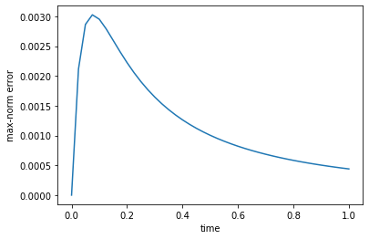

```python
plot(heat_solution_output.t,heat_solution_output.errors)
xlabel('time')
ylabel('max-norm error');
```

## Test for second-order accuracy

If dt and h are both reduced by 2, the error should go down by a factor 4 (for sufficiently small values).

Here we loop over a range of dt and h values, with dt = h in each solve.

```
   h         dt          error      ratio  estimated order
0.050000  0.050000    0.00180070     nan         nan
0.025000  0.025000    0.00043991    4.09        2.03
0.012500  0.012500    0.00010937    4.02        2.01
0.006250  0.006250    0.00002730    4.01        2.00
0.003125  0.003125    0.00000682    4.00        2.00
```

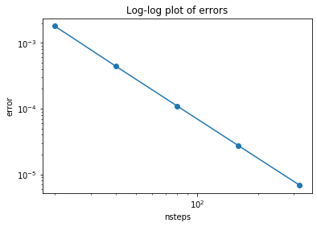

```python
nsteps_vals = [20,40,80,160,320]  # values to test
E = empty(len(nsteps_vals))

# print table header:
print("   h         dt          error      ratio  estimated order")

for j,nsteps in enumerate(nsteps_vals):
    heat_solution_input.nsteps = nsteps
    heat_solution_input.mx = nsteps - 1
    heat_solution_output = heat_CN(heat_solution_input)
    E[j] = heat_solution_output.errors[-1]  # last element
    h = heat_solution_output.h
    dt = heat_solution_output.dt

    if j>0:
        ratio = E[j-1] / E[j]
    else:
        ratio = nan

    p = log(ratio)/log(2)
    print("%8.6f  %8.6f  %12.8f    %4.2f        %4.2f" % (h, dt, E[j], ratio, p))

loglog(nsteps_vals, E, '-o')
title('Log-log plot of errors')
xlabel('nsteps')
ylabel('error')
```

## Observe oscillations if dt is too large

We know that Crank-Nicolson is stable for any time step, but the amplification factor approaches $-1$ as $k\lambda \rightarrow \infty$, so we expect high wavenumber modes to oscillate in time if we take the time step too large. This can be observed with the Gaussian initial data used here.

```python
heat_solution_input.mx = 39
heat_solution_input.nsteps = 2

heat_solution_output = heat_CN(heat_solution_input)

error_tfinal = heat_solution_output.errors[-1]  # last element
print('h = %6.4f, dt = %6.4f' % (heat_solution_output.h, heat_solution_output.dt))
print('Max-norm Error at t = %6.4f is %12.8f' % (heat_solution_input.tfinal, error_tfinal))

anim = make_animation(heat_solution_input, heat_solution_output)
HTML(anim.to_jshtml())  # or use the line below...
#HTML(anim.to_html5_video())
```

```
h = 0.0250, dt = 0.5000
Max-norm Error at t = 1.0000 is   0.08025302
```

[figure not shown]

Once Loop Reflect

### Discontinous data

With a sufficiently small time step, Crank-Nicolson behaves well on the problem with discontinous data. Note that we use an even number of grid points `m = 40` so that they are symmetric about $x=0$. Try `m=39` and see how the asymmetry gives a larger error!

```python
heat_solution_input = HeatSolutionInput()
heat_solution_input.t0 = 0.
heat_solution_input.tfinal = 1.5
heat_solution_input.ax = -1.
heat_solution_input.bx = 1.
heat_solution_input.mx = 40
heat_solution_input.utrue = utrue_erf
heat_solution_input.kappa = kappa
heat_solution_input.nsteps = 40

heat_solution_output = heat_CN(heat_solution_input)

error_tfinal = heat_solution_output.errors[-1]  # last element
print('h = %6.4f, dt = %6.4f' % (heat_solution_output.h, heat_solution_output.dt))
print('Max-norm Error at t = %6.4f is %12.8f' % (heat_solution_input.tfinal, error_tfinal))

anim = make_animation(heat_solution_input, heat_solution_output)
HTML(anim.to_jshtml())  # or use the line below...
#HTML(anim.to_html5_video())
```

```
h = 0.0488, dt = 0.0375
Max-norm Error at t = 1.5000 is   0.00254352
```

[figure not shown]

Once Loop Reflect

The issue with oscillations is more apparent with this discontinuous initial data. Taking a much larger time step on the same grid gives the results below. Note that the Crank-Nicolson method remains stable, but the saw-tooth mode is apparent near the interface if we try to step over the rapid transient behavior in this stiff problem.

```python
heat_solution_input.nsteps = 3

heat_solution_output = heat_CN(heat_solution_input)

error_tfinal = heat_solution_output.errors[-1]  # last element
print('h = %6.4f, dt = %6.4f' % (heat_solution_output.h, heat_solution_output.dt))
print('Max-norm Error at t = %6.4f is %12.8f' % (heat_solution_input.tfinal, error_tfinal))

anim = make_animation(heat_solution_input, heat_solution_output)
HTML(anim.to_jshtml())  # or use the line below...
#HTML(anim.to_html5_video())
```

```
h = 0.0488, dt = 0.5000
Max-norm Error at t = 1.5000 is   0.22870783
```

[figure not shown]

Once Loop Reflect

An L-stable method like TR-BDF2 would do better in this case.